# pcos-analysis-report

aurellaa

2025-03-08

# 1. Introduction

Polycystic ovary syndrome (PCOS) is a common multisystem disorder affecting the endocrine, reproductive, and metabolic systems in women of reproductive age. It is characterized by hyperandrogenism, chronic anovulation, and polycystic ovaries.<sup>1</sup> Moreover, it is the leading cause of infertility and is associated with a higher risk of developing type 2 diabetes, cardiovascular disease, and mental health disorders such as anxiety and depression.<sup>2</sup>

PCOS affects 8-13% of women in Australia.<sup>3</sup> However, despite its high prevalence, PCOS remains widely misunderstood and underdiagnosed. Many women experience delays in diagnosis and inadequate medical support, leading to long-term health consequences.<sup>4</sup>

This report conducts statistical analysis to answer these three research questions:

1. Does BMI Differ Between Women With and Without PCOS?

2. Are Irregular Periods Associated With Higher PCOS Risk?

3. Do Hormone Levels Differ Between PCOS and Non-PCOS Women?

The objective of this report is to help improve early diagnosis, treatment strategies, and screening guidelines for PCOS. Additionally, this report hopes to contribute to better public health awareness about PCOS, helping more women receive timely and effective medical care – ultimately improving their quality of life.

# 2. Data Preparation and Cleaning

## 2.1 Loading Required Packages

Before beginning the analysis, we load all necessary R packages to ensure smooth execution of the code.

```r
# loading in the necessary packages
library(ggplot2)
library(dplyr)
library(cowplot)
library(readxl)
library(effsize)
```

## 2.2 Loading the Dataset

```r
# loading in the dataset
pcos_data <- read_excel("PCOS_data_without_infertility.xlsx", sheet = 2)
```

## 2.3 Data Cleaning and Recoding

The following outlines the data preparation steps taken to ensure accuracy and readability:

```r
# removing the spaces from the variable names to prevent coding errors
colnames(pcos_data) <- gsub(" ", "_", colnames(pcos_data))
colnames(pcos_data)
```

```
##  [1] "Sl._No"                 "Patient_File_No."       "PCOS_(Y/N)"
##  [4] "Age_(yrs)"              "Weight_(Kg)"            "Height(Cm)"
##  [7] "BMI"                    "Blood_Group"            "Pulse_rate(bpm)"
## [10] "RR_(breaths/min)"       "Hb(g/dl)"               "Cycle(R/I)"
## [13] "Cycle_length(days)"     "Marraige_Status_(Yrs)"  "Pregnant(Y/N)"
## [16] "No._of_aborptions"      "I___beta-HCG(mIU/mL)"   "II____beta-HCG(mIU/mL)"
## [19] "FSH(mIU/mL)"            "LH(mIU/mL)"             "FSH/LH"
## [22] "Hip(inch)"              "Waist(inch)"            "Waist:Hip_Ratio"
## [25] "TSH_(mIU/L)"            "AMH(ng/mL)"             "PRL(ng/mL)"
## [28] "Vit_D3_(ng/mL)"         "PRG(ng/mL)"             "RBS(mg/dl)"
## [31] "Weight_gain(Y/N)"       "hair_growth(Y/N)"       "Skin_darkening_(Y/N)"
## [34] "Hair_loss(Y/N)"         "Pimples(Y/N)"           "Fast_food_(Y/N)"
## [37] "Reg.Exercise(Y/N)"      "BP__Systolic_(mmHg)"    "BP__Diastolic_(mmHg)"
## [40] "Follicle_No._(L)"       "Follicle_No._(R)"       "Avg._F_size_(L)_(mm)"
## [43] "Avg._F_size_(R)_(mm)"   "Endometrium_(mm)"       "...45"
```

```r
# only taking a subset of variables
pcos_data_subset <- pcos_data |>
  select(`PCOS_(Y/N)`,
         `Age_(yrs)`,
         `Weight_(Kg)`,
         `Height(Cm)`,
         BMI,
         `Cycle(R/I)`,
         `FSH(mIU/mL)`,
         `LH(mIU/mL)`,
         `FSH/LH`,
         `TSH_(mIU/L)`,
         `AMH(ng/mL)`,
         `PRL(ng/mL)`,
         `PRG(ng/mL)`,
         )

colnames(pcos_data_subset)
```

```
##  [1] "PCOS_(Y/N)"  "Age_(yrs)"   "Weight_(Kg)" "Height(Cm)"  "BMI"
##  [6] "Cycle(R/I)"  "FSH(mIU/mL)" "LH(mIU/mL)"  "FSH/LH"      "TSH_(mIU/L)"
## [11] "AMH(ng/mL)"  "PRL(ng/mL)"  "PRG(ng/mL)"
```

```r
# recoding variables to suit the analysis
# renaming some of the column names for convenience purposes
pcos_df <- pcos_data_subset |> rename(pcos = `PCOS_(Y/N)`,
                           age = `Age_(yrs)`,
                           weight = `Weight_(Kg)`,
                           height = `Height(Cm)`,
                           bmi = BMI,
                           cycle = `Cycle(R/I)`,
                           fsh = `FSH(mIU/mL)`,
                           lh = `LH(mIU/mL)`,
                           fsh_lh_ratio = `FSH/LH`,
                           tsh = `TSH_(mIU/L)`,
                           amh = `AMH(ng/mL)`,
                           prl = `PRL(ng/mL)`,
                           prg = `PRG(ng/mL)`,
                           )
glimpse(pcos_df)
```

```
## Rows: 541
## Columns: 13
## $ pcos         <dbl> 0, 0, 1, 0, 0, 0, 0, 0, 0, 0, 0, 0, 1, 0, 0, 0, 0, 0, 0, …
## $ age          <dbl> 28, 36, 33, 37, 25, 36, 34, 33, 32, 36, 20, 26, 25, 38, 3…
## $ weight       <dbl> 44.6, 65.0, 68.8, 65.0, 52.0, 74.1, 64.0, 58.5, 40.0, 52.…
## $ height       <dbl> 152.0, 161.5, 165.0, 148.0, 161.0, 165.0, 156.0, 159.0, 1…
## $ bmi          <dbl> 19.30000, 24.92116, 25.27089, 29.67495, 20.06095, 27.2176…
## $ cycle        <dbl> 2, 2, 2, 2, 2, 2, 2, 2, 2, 4, 2, 2, 4, 2, 2, 2, 2, 2, 2, …
## $ fsh          <dbl> 7.95, 6.73, 5.54, 8.06, 3.98, 3.24, 2.85, 4.86, 3.76, 2.8…
## $ lh           <dbl> 3.68, 1.09, 0.88, 2.36, 0.90, 1.07, 0.31, 3.07, 3.02, 1.5…
## $ fsh_lh_ratio <dbl> 2.160326, 6.174312, 6.295455, 3.415254, 4.422222, 3.02803…
## $ tsh          <dbl> 0.68, 3.16, 2.54, 16.41, 3.57, 1.60, 1.51, 12.18, 1.51, 6…
## $ amh          <chr> "2.07", "1.53", "6.63", "1.22", "2.26", "6.74", "3.05", "…
## $ prl          <dbl> 45.16, 20.09, 10.52, 36.90, 30.09, 16.18, 26.41, 3.97, 19…
## $ prg          <dbl> 0.57, 0.97, 0.36, 0.36, 0.38, 0.30, 0.46, 0.26, 0.30, 0.2…
```

```r
# correcting the data types of each variable
str(pcos_df)
```

```
## tibble [541 × 13] (S3: tbl_df/tbl/data.frame)
##  $ pcos        : num [1:541] 0 0 1 0 0 0 0 0 0 0 ...
##  $ age         : num [1:541] 28 36 33 37 25 36 34 33 32 36 ...
##  $ weight      : num [1:541] 44.6 65 68.8 65 52 74.1 64 58.5 40 52 ...
##  $ height      : num [1:541] 152 162 165 148 161 ...
##  $ bmi         : num [1:541] 19.3 24.9 25.3 29.7 20.1 ...
##  $ cycle       : num [1:541] 2 2 2 2 2 2 2 2 2 4 ...
##  $ fsh         : num [1:541] 7.95 6.73 5.54 8.06 3.98 3.24 2.85 4.86 3.76 2.8 ...
##  $ lh          : num [1:541] 3.68 1.09 0.88 2.36 0.9 1.07 0.31 3.07 3.02 1.51 ...
##  $ fsh_lh_ratio: num [1:541] 2.16 6.17 6.3 3.42 4.42 ...
##  $ tsh         : num [1:541] 0.68 3.16 2.54 16.41 3.57 ...
##  $ amh         : chr [1:541] "2.07" "1.53" "6.63" "1.22" ...
##  $ prl         : num [1:541] 45.2 20.1 10.5 36.9 30.1 ...
##  $ prg         : num [1:541] 0.57 0.97 0.36 0.36 0.38 0.3 0.46 0.26 0.3 0.25 ...
```

```r
pcos_df <- pcos_df |>
  mutate(
    pcos = as.factor(pcos),  # Convert PCOS (Yes/No) to categorical
    cycle = as.factor(cycle),  # Regular/Irregular as categorical
    age = as.numeric(age),
    weight = as.numeric(weight),
    height = as.numeric(height),
    bmi = as.numeric(bmi),
    fsh = as.numeric(fsh),
    lh = as.numeric(lh),
    fsh_lh_ratio = as.numeric(fsh_lh_ratio),
    tsh = as.numeric(tsh),
    amh = as.numeric(amh),
    prl = as.numeric(prl),
    prg = as.numeric(prg),
  )
# an error was thrown. let's see what's happening...

pcos_df |> filter(is.na(as.numeric(amh)))
```

```
## # A tibble: 1 × 13
##   pcos    age weight height   bmi cycle   fsh    lh fsh_lh_ratio   tsh   amh
##   <fct> <dbl>  <dbl>  <dbl> <dbl> <fct> <dbl> <dbl>        <dbl> <dbl> <dbl>
## 1 0        37     56    152  24.2 2      2.91  0.35         8.31    16    NA
## # ℹ 2 more variables: prl <dbl>, prg <dbl>
```

```r
# unfortunately there seem to be some typographical errors in the data.
# for instance, row 307 amh is listed as "a". we should omit that.
```

```r
# checking for any other NAs
colSums(is.na(pcos_df))
```

```
##         pcos          age       weight       height          bmi        cycle
##            0            0            0            0            0            0
##          fsh           lh fsh_lh_ratio          tsh          amh          prl
##            0            0            0            0            1            0
##          prg
##            0
```

```r
pcos_df <- na.omit(pcos_df)
```

```r
# let's convert the binary variables values into being words instead
# of numerical values, for clarity.

# changing pcos values such that 0 = No, 1 = Yes
## checking for any possible data input errors
table(pcos_df$pcos)
```

```
##
##   0   1
## 363 177
```

```r
pcos_df <- pcos_df |>
  mutate(pcos = ifelse(pcos == 0, "No", "Yes"))
table(pcos_df$pcos)
```

```
##
##  No Yes
## 363 177
```

```r
# changing cycle values such that 2 = "regular" and 4 = "irregular"
## checking for any possible data input errors
table(pcos_df$cycle)
```

```
##
##   2   4   5
## 389 150   1
```

```r
## it seems that there is mistakenly one "5". we will get rid of this observation
pcos_df <- pcos_df |> filter(cycle != 5)
table(pcos_df$cycle)
```

```
##
##   2   4   5
## 389 150   0
```

```r
# pcos_df will now be down to 539 observations

pcos_df <- pcos_df |>
  mutate(cycle = ifelse(cycle == 2, "Regular", "Irregular"))

glimpse(pcos_df)
```

```
## Rows: 539
## Columns: 13
## $ pcos         <chr> "No", "No", "Yes", "No", "No", "No", "No", "No", "No", "N…
## $ age          <dbl> 28, 36, 33, 37, 25, 36, 34, 33, 32, 36, 20, 26, 25, 38, 3…
## $ weight       <dbl> 44.6, 65.0, 68.8, 65.0, 52.0, 74.1, 64.0, 58.5, 40.0, 52.…
## $ height       <dbl> 152.0, 161.5, 165.0, 148.0, 161.0, 165.0, 156.0, 159.0, 1…
## $ bmi          <dbl> 19.30000, 24.92116, 25.27089, 29.67495, 20.06095, 27.2176…
## $ cycle        <chr> "Regular", "Regular", "Regular", "Regular", "Regular", "R…
## $ fsh          <dbl> 7.95, 6.73, 5.54, 8.06, 3.98, 3.24, 2.85, 4.86, 3.76, 2.8…
## $ lh           <dbl> 3.68, 1.09, 0.88, 2.36, 0.90, 1.07, 0.31, 3.07, 3.02, 1.5…
## $ fsh_lh_ratio <dbl> 2.160326, 6.174312, 6.295455, 3.415254, 4.422222, 3.02803…
## $ tsh          <dbl> 0.68, 3.16, 2.54, 16.41, 3.57, 1.60, 1.51, 12.18, 1.51, 6…
## $ amh          <dbl> 2.07, 1.53, 6.63, 1.22, 2.26, 6.74, 3.05, 1.54, 1.00, 1.6…
## $ prl          <dbl> 45.16, 20.09, 10.52, 36.90, 30.09, 16.18, 26.41, 3.97, 19…
## $ prg          <dbl> 0.57, 0.97, 0.36, 0.36, 0.38, 0.30, 0.46, 0.26, 0.30, 0.2…
```

```r
pcos_df <- pcos_df |>
  mutate(
    pcos = as.factor(pcos),  # Convert PCOS (Yes/No) to categorical
    cycle = as.factor(cycle),  # Regular/Irregular as categorical
    age = as.numeric(age),
    weight = as.numeric(weight),
    height = as.numeric(height),
    bmi = as.numeric(bmi),
    fsh = as.numeric(fsh),
    lh = as.numeric(lh),
    fsh_lh_ratio = as.numeric(fsh_lh_ratio),
    tsh = as.numeric(tsh),
    amh = as.numeric(amh),
    prl = as.numeric(prl),
    prg = as.numeric(prg),
  )

pcos_df # the data is now clean and ready for analysis
```

```
## # A tibble: 539 × 13
##    pcos    age weight height   bmi cycle      fsh    lh fsh_lh_ratio   tsh   amh
##    <fct> <dbl>  <dbl>  <dbl> <dbl> <fct>    <dbl> <dbl>        <dbl> <dbl> <dbl>
##  1 No       28   44.6   152   19.3 Regular   7.95  3.68         2.16  0.68  2.07
##  2 No       36   65     162.  24.9 Regular   6.73  1.09         6.17  3.16  1.53
##  3 Yes      33   68.8   165   25.3 Regular   5.54  0.88         6.30  2.54  6.63
##  4 No       37   65     148   29.7 Regular   8.06  2.36         3.42 16.4   1.22
##  5 No       25   52     161   20.1 Regular   3.98  0.9          4.42  3.57  2.26
##  6 No       36   74.1   165   27.2 Regular   3.24  1.07         3.03  1.6   6.74
##  7 No       34   64     156   26.3 Regular   2.85  0.31         9.19  1.51  3.05
##  8 No       33   58.5   159   23.1 Regular   4.86  3.07         1.58 12.2   1.54
##  9 No       32   40     158   16.0 Regular   3.76  3.02         1.25  1.51  1
## 10 No       36   52     150   23.1 Irregul…  2.8   1.51         1.85  6.65  1.61
## # ℹ 529 more rows
## # ℹ 2 more variables: prl <dbl>, prg <dbl>
```

# 3. Summary Statistics

Before conducting further analysis, we examine the summary statistics of the cleaned dataset.

```r
# summary stats
summary(pcos_df)
```

```
##   pcos          age            weight           height           bmi
##  No :363   Min.   :20.00   Min.   : 31.00   Min.   :137.0   Min.   :12.42
##  Yes:176   1st Qu.:28.00   1st Qu.: 52.00   1st Qu.:152.0   1st Qu.:21.64
##            Median :31.00   Median : 59.00   Median :156.0   Median :24.22
##            Mean   :31.44   Mean   : 59.62   Mean   :156.5   Mean   :24.31
##            3rd Qu.:35.00   3rd Qu.: 65.00   3rd Qu.:160.0   3rd Qu.:26.65
##            Max.   :48.00   Max.   :108.00   Max.   :180.0   Max.   :38.90
##        cycle          fsh                 lh            fsh_lh_ratio
##  Irregular:150   Min.   :   0.210   Min.   :   0.020   Min.   :   0.0021
##  Regular  :389   1st Qu.:   3.335   1st Qu.:   1.025   1st Qu.:   1.4148
##                  Median :   4.860   Median :   2.300   Median :   2.1612
##                  Mean   :  14.647   Mean   :   6.492   Mean   :   6.9081
##                  3rd Qu.:   6.415   3rd Qu.:   3.680   3rd Qu.:   3.9493
##                  Max.   :5052.000   Max.   :2018.000   Max.   :1372.8261
##       tsh              amh              prl              prg
##  Min.   : 0.040   Min.   : 0.100   Min.   :  0.40   Min.   : 0.0470
##  1st Qu.: 1.480   1st Qu.: 2.010   1st Qu.: 14.52   1st Qu.: 0.2500
##  Median : 2.260   Median : 3.700   Median : 21.92   Median : 0.3200
##  Mean   : 2.961   Mean   : 5.624   Mean   : 24.38   Mean   : 0.6122
##  3rd Qu.: 3.570   3rd Qu.: 6.950   3rd Qu.: 29.93   3rd Qu.: 0.4550
##  Max.   :65.000   Max.   :66.000   Max.   :128.24   Max.   :85.0000
```

# 4. Research Question 1: Does BMI Differ Between Women With and Without PCOS?

### 4.1 Setting a Global Theme

```r
#### global theme
theme_set(
  theme_classic()
)
```

### 4.2 Visualising the Distribution of the Data

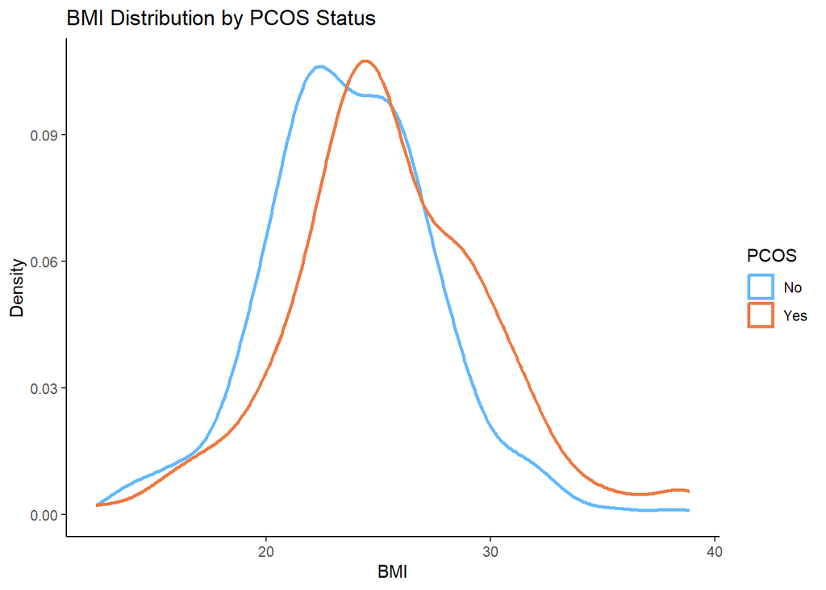

```r
#### density plot

ggplot(pcos_df, aes(x=bmi, color = pcos)) +
  geom_density(lwd = 1) +
  labs(x = "BMI", y = "Density", title = "BMI Distribution by PCOS Status", color = "PCOS") +
  scale_color_manual(values = c("No" = "steelblue1", "Yes" = "sienna2"))
```

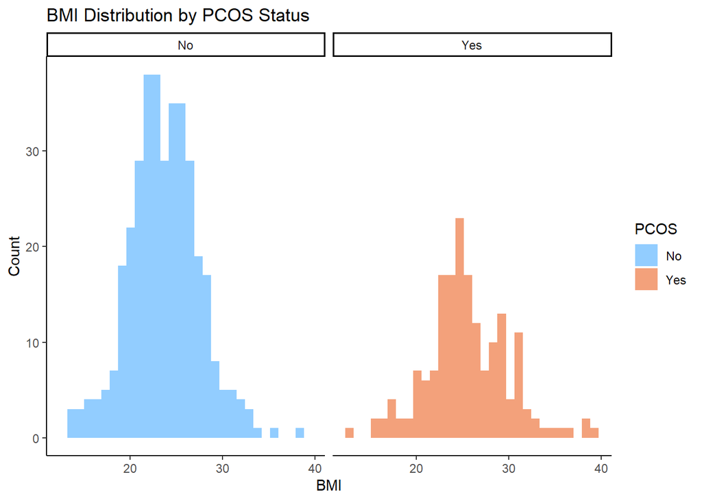

```r
#### histogram faceted by pcos
ggplot(pcos_df, aes(x = bmi, fill = pcos)) +
  geom_histogram(alpha = 0.7, position = "identity", bins = 30) +
  facet_wrap(~ pcos) +
  labs(x = "BMI", y = "Count", fill = "PCOS", title = "BMI Distribution by PCOS Status") +
  scale_fill_manual(values = c("No" = "steelblue1", "Yes" = "sienna2"))
```

While the non-PCOS seems to be roughly normally distributed, it seems like the PCOS group could have some skewness.